# Risk Factor Analysis

## Outcome Variable

**Outcome Variable:** whz

## Predictor Variables

**Intervention Variable:** mbmi

**Adjustment Set:**

- arm
- W_mage
- W_fage
- meducyrs
- feducyrs
- single
- brthmon
- W_gagebrth
- W_birthwt
- W_birthlen
- vagbrth
- delta_W_mage
- delta_W_fage
- delta_meducyrs
- delta_feducyrs
- delta_single
- delta_brthmon
- delta_W_gagebrth
- delta_W_birthwt
- delta_W_birthlen
- delta_vagbrth

## Stratifying Variables

The analysis was stratified on these variable(s):

- agecat
- studyid
- country

## Data Summary

| agecat | studyid | country | mbmi | n_cell | n |
| --- | --- | --- | --- | --- | --- |
| 6 months | ki0047075b-MAL-ED | BANGLADESH | Normal weight | 209 | 241 |
| 6 months | ki0047075b-MAL-ED | BANGLADESH | Underweight | 32 | 241 |
| 6 months | ki0047075b-MAL-ED | BRAZIL | Normal weight | 199 | 208 |
| 6 months | ki0047075b-MAL-ED | BRAZIL | Underweight | 9 | 208 |
| 6 months | ki0047075b-MAL-ED | INDIA | Normal weight | 186 | 235 |
| 6 months | ki0047075b-MAL-ED | INDIA | Underweight | 49 | 235 |
| 6 months | ki0047075b-MAL-ED | NEPAL | Normal weight | 236 | 236 |
| 6 months | ki0047075b-MAL-ED | NEPAL | Underweight | 0 | 236 |
| 6 months | ki0047075b-MAL-ED | PERU | Normal weight | 267 | 272 |
| 6 months | ki0047075b-MAL-ED | PERU | Underweight | 5 | 272 |
| 6 months | ki0047075b-MAL-ED | SOUTH AFRICA | Normal weight | 242 | 249 |
| 6 months | ki0047075b-MAL-ED | SOUTH AFRICA | Underweight | 7 | 249 |
| 6 months | ki0047075b-MAL-ED | TANZANIA, UNITED REPUBLIC OF | Normal weight | 233 | 247 |
| 6 months | ki0047075b-MAL-ED | TANZANIA, UNITED REPUBLIC OF | Underweight | 14 | 247 |
| 6 months | ki1000304b-SAS-CompFeed | INDIA | Normal weight | 921 | 1225 |
| 6 months | ki1000304b-SAS-CompFeed | INDIA | Underweight | 304 | 1225 |
| 6 months | ki1017093-NIH-Birth | BANGLADESH | Normal weight | 443 | 536 |
| 6 months | ki1017093-NIH-Birth | BANGLADESH | Underweight | 93 | 536 |
| 6 months | ki1017093b-PROVIDE | BANGLADESH | Normal weight | 480 | 581 |
| 6 months | ki1017093b-PROVIDE | BANGLADESH | Underweight | 101 | 581 |
| 6 months | ki1017093c-NIH-Crypto | BANGLADESH | Normal weight | 648 | 715 |
| 6 months | ki1017093c-NIH-Crypto | BANGLADESH | Underweight | 67 | 715 |
| 6 months | ki1066203-TanzaniaChild2 | TANZANIA, UNITED REPUBLIC OF | Normal weight | 1949 | 1982 |
| 6 months | ki1066203-TanzaniaChild2 | TANZANIA, UNITED REPUBLIC OF | Underweight | 33 | 1982 |
| 6 months | ki1119695-PROBIT | BELARUS | Normal weight | 12519 | 13024 |
| 6 months | ki1119695-PROBIT | BELARUS | Underweight | 505 | 13024 |
| 6 months | ki1126311-ZVITAMBO | ZIMBABWE | Normal weight | 6726 | 7087 |
| 6 months | ki1126311-ZVITAMBO | ZIMBABWE | Underweight | 361 | 7087 |
| 6 months | ki1148112-LCNI-5 | MALAWI | Normal weight | 691 | 836 |
| 6 months | ki1148112-LCNI-5 | MALAWI | Underweight | 145 | 836 |
| 24 months | ki0047075b-MAL-ED | BANGLADESH | Normal weight | 183 | 212 |
| 24 months | ki0047075b-MAL-ED | BANGLADESH | Underweight | 29 | 212 |
| 24 months | ki0047075b-MAL-ED | BRAZIL | Normal weight | 162 | 168 |
| 24 months | ki0047075b-MAL-ED | BRAZIL | Underweight | 6 | 168 |
| 24 months | ki0047075b-MAL-ED | INDIA | Normal weight | 180 | 226 |
| 24 months | ki0047075b-MAL-ED | INDIA | Underweight | 46 | 226 |
| 24 months | ki0047075b-MAL-ED | NEPAL | Normal weight | 228 | 228 |
| 24 months | ki0047075b-MAL-ED | NEPAL | Underweight | 0 | 228 |
| 24 months | ki0047075b-MAL-ED | PERU | Normal weight | 197 | 201 |
| 24 months | ki0047075b-MAL-ED | PERU | Underweight | 4 | 201 |
| 24 months | ki0047075b-MAL-ED | SOUTH AFRICA | Normal weight | 227 | 234 |
| 24 months | ki0047075b-MAL-ED | SOUTH AFRICA | Underweight | 7 | 234 |
| 24 months | ki0047075b-MAL-ED | TANZANIA, UNITED REPUBLIC OF | Normal weight | 203 | 214 |
| 24 months | ki0047075b-MAL-ED | TANZANIA, UNITED REPUBLIC OF | Underweight | 11 | 214 |
| 24 months | ki1017093-NIH-Birth | BANGLADESH | Normal weight | 348 | 428 |
| 24 months | ki1017093-NIH-Birth | BANGLADESH | Underweight | 80 | 428 |
| 24 months | ki1017093b-PROVIDE | BANGLADESH | Normal weight | 477 | 577 |
| 24 months | ki1017093b-PROVIDE | BANGLADESH | Underweight | 100 | 577 |
| 24 months | ki1017093c-NIH-Crypto | BANGLADESH | Normal weight | 471 | 514 |
| 24 months | ki1017093c-NIH-Crypto | BANGLADESH | Underweight | 43 | 514 |
| 24 months | ki1066203-TanzaniaChild2 | TANZANIA, UNITED REPUBLIC OF | Normal weight | 6 | 6 |
| 24 months | ki1066203-TanzaniaChild2 | TANZANIA, UNITED REPUBLIC OF | Underweight | 0 | 6 |
| 24 months | ki1119695-PROBIT | BELARUS | Normal weight | 3800 | 3941 |
| 24 months | ki1119695-PROBIT | BELARUS | Underweight | 141 | 3941 |
| 24 months | ki1126311-ZVITAMBO | ZIMBABWE | Normal weight | 334 | 359 |
| 24 months | ki1126311-ZVITAMBO | ZIMBABWE | Underweight | 25 | 359 |
| 24 months | ki1148112-LCNI-5 | MALAWI | Normal weight | 467 | 561 |
| 24 months | ki1148112-LCNI-5 | MALAWI | Underweight | 94 | 561 |

The following strata were considered:

- agecat: 24 months, studyid: ki0047075b-MAL-ED, country: BANGLADESH
- agecat: 24 months, studyid: ki0047075b-MAL-ED, country: BRAZIL
- agecat: 24 months, studyid: ki0047075b-MAL-ED, country: INDIA
- agecat: 24 months, studyid: ki0047075b-MAL-ED, country: NEPAL
- agecat: 24 months, studyid: ki0047075b-MAL-ED, country: PERU
- agecat: 24 months, studyid: ki0047075b-MAL-ED, country: SOUTH AFRICA
- agecat: 24 months, studyid: ki0047075b-MAL-ED, country: TANZANIA, UNITED REPUBLIC OF
- agecat: 24 months, studyid: ki1017093-NIH-Birth, country: BANGLADESH
- agecat: 24 months, studyid: ki1017093b-PROVIDE, country: BANGLADESH
- agecat: 24 months, studyid: ki1017093c-NIH-Crypto, country: BANGLADESH
- agecat: 24 months, studyid: ki1066203-TanzaniaChild2, country: TANZANIA, UNITED REPUBLIC OF
- agecat: 24 months, studyid: ki1119695-PROBIT, country: BELARUS
- agecat: 24 months, studyid: ki1126311-ZVITAMBO, country: ZIMBABWE
- agecat: 24 months, studyid: ki1148112-LCNI-5, country: MALAWI
- agecat: 6 months, studyid: ki0047075b-MAL-ED, country: BANGLADESH
- agecat: 6 months, studyid: ki0047075b-MAL-ED, country: BRAZIL
- agecat: 6 months, studyid: ki0047075b-MAL-ED, country: INDIA
- agecat: 6 months, studyid: ki0047075b-MAL-ED, country: NEPAL
- agecat: 6 months, studyid: ki0047075b-MAL-ED, country: PERU
- agecat: 6 months, studyid: ki0047075b-MAL-ED, country: SOUTH AFRICA
- agecat: 6 months, studyid: ki0047075b-MAL-ED, country: TANZANIA, UNITED REPUBLIC OF
- agecat: 6 months, studyid: ki1000304b-SAS-CompFeed, country: INDIA
- agecat: 6 months, studyid: ki1017093-NIH-Birth, country: BANGLADESH
- agecat: 6 months, studyid: ki1017093b-PROVIDE, country: BANGLADESH
- agecat: 6 months, studyid: ki1017093c-NIH-Crypto, country: BANGLADESH
- agecat: 6 months, studyid: ki1066203-TanzaniaChild2, country: TANZANIA, UNITED REPUBLIC OF
- agecat: 6 months, studyid: ki1119695-PROBIT, country: BELARUS
- agecat: 6 months, studyid: ki1126311-ZVITAMBO, country: ZIMBABWE
- agecat: 6 months, studyid: ki1148112-LCNI-5, country: MALAWI

### Dropped Strata

Some strata were dropped due to rare outcomes:

- agecat: 6 months, studyid: ki0047075b-MAL-ED, country: NEPAL
- agecat: 24 months, studyid: ki0047075b-MAL-ED, country: NEPAL
- agecat: 24 months, studyid: ki0047075b-MAL-ED, country: PERU
- agecat: 24 months, studyid: ki1066203-TanzaniaChild2, country: TANZANIA, UNITED REPUBLIC OF

## Methods Detail

We’re interested in the causal parameters $E[Y_a]$ for all values of $a \in \mathcal{A}$. These parameters represent the mean outcome if, possibly contrary to fact, we intervened to set all units to have $A=a$. Under the randomization and positivity assumptions, these are identified by the statistical parameters $\psi_a=E_W[E_{Y|A,W}(Y|A=a,W)]$. In addition, we’re interested in the mean of $Y$, $E[Y]$ under no intervention (the observed mean). We will estimate these parameters by using SuperLearner to fit the relevant likelihood factors – $E_{Y|A,W}(Y|A=a,W)$ and $p(A=a|W)$, and then updating our likelihood fit using a joint TMLE.

For unadjusted analyses ($W=\{\}$), initial likelihoods were estimated using Lrnr_glm to estimate the simple $E(Y|A)$ and Lrnr_mean to estimate $p(A)$. For adjusted analyses, a small library containing Lrnr_glmnet, Lrnr_xgboost, and Lrnr_mean was used.

Having estimated these parameters, we will then use the delta method to estimate relative risks and attributable risks relative to a prespecified baseline level of $A$.

# Results Detail

## Results Plots

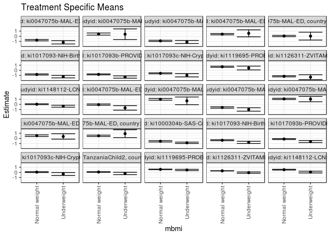

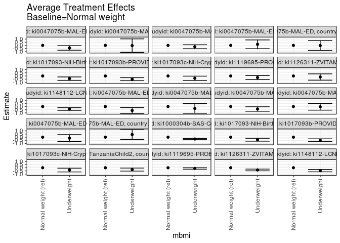

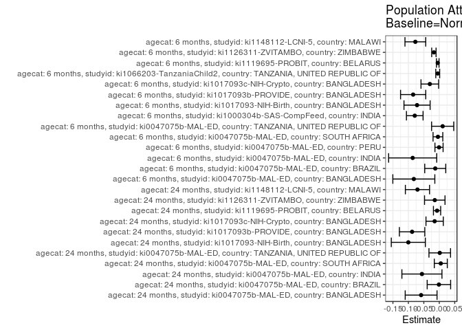

## Results Table

### Parameter: TSM

| agecat | studyid | country | intervention_level | baseline_level | estimate | ci_lower | ci_upper |
| --- | --- | --- | --- | --- | --- | --- | --- |
| 6 months | ki0047075b-MAL-ED | BANGLADESH | Normal weight | NA | -0.0574553 | -0.1870853 | 0.0721747 |
| 6 months | ki0047075b-MAL-ED | BANGLADESH | Underweight | NA | -0.6866731 | -1.1331539 | -0.2401923 |
| 6 months | ki0047075b-MAL-ED | BRAZIL | Normal weight | NA | 0.9775209 | 0.8091090 | 1.1459329 |
| 6 months | ki0047075b-MAL-ED | BRAZIL | Underweight | NA | 0.6764815 | -0.0674862 | 1.4204491 |
| 6 months | ki0047075b-MAL-ED | INDIA | Normal weight | NA | -0.6127207 | -0.7430253 | -0.4824162 |
| 6 months | ki0047075b-MAL-ED | INDIA | Underweight | NA | -0.9991069 | -1.3292912 | -0.6689226 |
| 6 months | ki0047075b-MAL-ED | PERU | Normal weight | NA | 1.0571910 | 0.9326684 | 1.1817136 |
| 6 months | ki0047075b-MAL-ED | PERU | Underweight | NA | 1.0130000 | 0.5008674 | 1.5251326 |
| 6 months | ki0047075b-MAL-ED | SOUTH AFRICA | Normal weight | NA | 0.5333953 | 0.3757046 | 0.6910860 |
| 6 months | ki0047075b-MAL-ED | SOUTH AFRICA | Underweight | NA | 0.3785714 | -0.1478585 | 0.9050014 |
| 6 months | ki0047075b-MAL-ED | TANZANIA, UNITED REPUBLIC OF | Normal weight | NA | 0.5060886 | 0.3710738 | 0.6411034 |
| 6 months | ki0047075b-MAL-ED | TANZANIA, UNITED REPUBLIC OF | Underweight | NA | 0.9212981 | 0.1561140 | 1.6864822 |
| 6 months | ki1000304b-SAS-CompFeed | INDIA | Normal weight | NA | -0.5647696 | -0.6966524 | -0.4328869 |
| 6 months | ki1000304b-SAS-CompFeed | INDIA | Underweight | NA | -0.8594544 | -0.9885709 | -0.7303378 |
| 6 months | ki1017093-NIH-Birth | BANGLADESH | Normal weight | NA | -0.3669816 | -0.4642952 | -0.2696681 |
| 6 months | ki1017093-NIH-Birth | BANGLADESH | Underweight | NA | -0.7734925 | -0.9816306 | -0.5653545 |
| 6 months | ki1017093b-PROVIDE | BANGLADESH | Normal weight | NA | -0.1234785 | -0.2148989 | -0.0320582 |
| 6 months | ki1017093b-PROVIDE | BANGLADESH | Underweight | NA | -0.6107102 | -0.8146722 | -0.4067481 |
| 6 months | ki1017093c-NIH-Crypto | BANGLADESH | Normal weight | NA | 0.0603263 | -0.0214123 | 0.1420649 |
| 6 months | ki1017093c-NIH-Crypto | BANGLADESH | Underweight | NA | -0.3035502 | -0.5905544 | -0.0165459 |
| 6 months | ki1066203-TanzaniaChild2 | TANZANIA, UNITED REPUBLIC OF | Normal weight | NA | 0.0825300 | 0.0281478 | 0.1369123 |
| 6 months | ki1066203-TanzaniaChild2 | TANZANIA, UNITED REPUBLIC OF | Underweight | NA | -0.2028875 | -0.4342530 | 0.0284779 |
| 6 months | ki1119695-PROBIT | BELARUS | Normal weight | NA | 0.5879709 | 0.5298833 | 0.6460585 |
| 6 months | ki1119695-PROBIT | BELARUS | Underweight | NA | 0.4778451 | 0.3506586 | 0.6050315 |
| 6 months | ki1126311-ZVITAMBO | ZIMBABWE | Normal weight | NA | 0.3102303 | 0.2816894 | 0.3387712 |
| 6 months | ki1126311-ZVITAMBO | ZIMBABWE | Underweight | NA | -0.0365241 | -0.1737068 | 0.1006585 |
| 6 months | ki1148112-LCNI-5 | MALAWI | Normal weight | NA | 0.5289703 | 0.4506706 | 0.6072701 |
| 6 months | ki1148112-LCNI-5 | MALAWI | Underweight | NA | 0.0684794 | -0.0996489 | 0.2366078 |
| 24 months | ki0047075b-MAL-ED | BANGLADESH | Normal weight | NA | -0.7620788 | -0.8923682 | -0.6317895 |
| 24 months | ki0047075b-MAL-ED | BANGLADESH | Underweight | NA | -1.1701630 | -1.4995326 | -0.8407933 |
| 24 months | ki0047075b-MAL-ED | BRAZIL | Normal weight | NA | 0.4294444 | 0.2224555 | 0.6364334 |
| 24 months | ki0047075b-MAL-ED | BRAZIL | Underweight | NA | 0.3966667 | -0.6451983 | 1.4385316 |
| 24 months | ki0047075b-MAL-ED | INDIA | Normal weight | NA | -0.8964351 | -1.0203199 | -0.7725502 |
| 24 months | ki0047075b-MAL-ED | INDIA | Underweight | NA | -1.1157123 | -1.4081315 | -0.8232931 |
| 24 months | ki0047075b-MAL-ED | SOUTH AFRICA | Normal weight | NA | 0.4046696 | 0.2835400 | 0.5257992 |
| 24 months | ki0047075b-MAL-ED | SOUTH AFRICA | Underweight | NA | 0.5700000 | -0.1123856 | 1.2523856 |
| 24 months | ki0047075b-MAL-ED | TANZANIA, UNITED REPUBLIC OF | Normal weight | NA | 0.0485318 | -0.0785951 | 0.1756587 |
| 24 months | ki0047075b-MAL-ED | TANZANIA, UNITED REPUBLIC OF | Underweight | NA | 0.0263244 | -0.7364552 | 0.7891041 |
| 24 months | ki1017093-NIH-Birth | BANGLADESH | Normal weight | NA | -0.8113980 | -0.9147022 | -0.7080938 |
| 24 months | ki1017093-NIH-Birth | BANGLADESH | Underweight | NA | -1.2333168 | -1.4789912 | -0.9876425 |
| 24 months | ki1017093b-PROVIDE | BANGLADESH | Normal weight | NA | -0.7985557 | -0.8878620 | -0.7092493 |
| 24 months | ki1017093b-PROVIDE | BANGLADESH | Underweight | NA | -1.3058387 | -1.5256945 | -1.0859829 |
| 24 months | ki1017093c-NIH-Crypto | BANGLADESH | Normal weight | NA | -0.5953613 | -0.6946005 | -0.4961222 |
| 24 months | ki1017093c-NIH-Crypto | BANGLADESH | Underweight | NA | -0.9607603 | -1.2819162 | -0.6396045 |
| 24 months | ki1119695-PROBIT | BELARUS | Normal weight | NA | 0.6941510 | 0.5842355 | 0.8040666 |
| 24 months | ki1119695-PROBIT | BELARUS | Underweight | NA | 0.4432443 | 0.0733996 | 0.8130890 |
| 24 months | ki1126311-ZVITAMBO | ZIMBABWE | Normal weight | NA | -1.1664648 | -1.2806718 | -1.0522579 |
| 24 months | ki1126311-ZVITAMBO | ZIMBABWE | Underweight | NA | -1.3316513 | -1.8127476 | -0.8505550 |
| 24 months | ki1148112-LCNI-5 | MALAWI | Normal weight | NA | 0.0236154 | -0.0663924 | 0.1136232 |
| 24 months | ki1148112-LCNI-5 | MALAWI | Underweight | NA | -0.3681541 | -0.5568178 | -0.1794904 |

### Parameter: E(Y)

| agecat | studyid | country | intervention_level | baseline_level | estimate | ci_lower | ci_upper |
| --- | --- | --- | --- | --- | --- | --- | --- |
| 6 months | ki0047075b-MAL-ED | BANGLADESH | NA | NA | -0.1397960 | -0.2688682 | -0.0107238 |
| 6 months | ki0047075b-MAL-ED | BRAZIL | NA | NA | 0.9644952 | 0.7999744 | 1.1290160 |
| 6 months | ki0047075b-MAL-ED | INDIA | NA | NA | -0.6987943 | -0.8241325 | -0.5734561 |
| 6 months | ki0047075b-MAL-ED | PERU | NA | NA | 1.0563787 | 0.9342938 | 1.1784635 |
| 6 months | ki0047075b-MAL-ED | SOUTH AFRICA | NA | NA | 0.5290428 | 0.3750394 | 0.6830463 |
| 6 months | ki0047075b-MAL-ED | TANZANIA, UNITED REPUBLIC OF | NA | NA | 0.5170513 | 0.3872178 | 0.6468847 |
| 6 months | ki1000304b-SAS-CompFeed | INDIA | NA | NA | -0.6441020 | -0.7710827 | -0.5171213 |
| 6 months | ki1017093-NIH-Birth | BANGLADESH | NA | NA | -0.4389101 | -0.5279432 | -0.3498771 |
| 6 months | ki1017093b-PROVIDE | BANGLADESH | NA | NA | -0.2079891 | -0.2925599 | -0.1234183 |
| 6 months | ki1017093c-NIH-Crypto | BANGLADESH | NA | NA | 0.0297622 | -0.0491685 | 0.1086930 |
| 6 months | ki1066203-TanzaniaChild2 | TANZANIA, UNITED REPUBLIC OF | NA | NA | 0.0775172 | 0.0241750 | 0.1308595 |
| 6 months | ki1119695-PROBIT | BELARUS | NA | NA | 0.5829956 | 0.5247249 | 0.6412663 |
| 6 months | ki1126311-ZVITAMBO | ZIMBABWE | NA | NA | 0.2928094 | 0.2648167 | 0.3208020 |
| 6 months | ki1148112-LCNI-5 | MALAWI | NA | NA | 0.4515431 | 0.3802415 | 0.5228446 |
| 24 months | ki0047075b-MAL-ED | BANGLADESH | NA | NA | -0.8208255 | -0.9429246 | -0.6987264 |
| 24 months | ki0047075b-MAL-ED | BRAZIL | NA | NA | 0.4282738 | 0.2252365 | 0.6313111 |
| 24 months | ki0047075b-MAL-ED | INDIA | NA | NA | -0.9525664 | -1.0684455 | -0.8366872 |
| 24 months | ki0047075b-MAL-ED | SOUTH AFRICA | NA | NA | 0.4096154 | 0.2902946 | 0.5289362 |
| 24 months | ki0047075b-MAL-ED | TANZANIA, UNITED REPUBLIC OF | NA | NA | 0.0500935 | -0.0748234 | 0.1750103 |
| 24 months | ki1017093-NIH-Birth | BANGLADESH | NA | NA | -0.9115790 | -1.0095022 | -0.8136559 |
| 24 months | ki1017093b-PROVIDE | BANGLADESH | NA | NA | -0.8864991 | -0.9695215 | -0.8034768 |
| 24 months | ki1017093c-NIH-Crypto | BANGLADESH | NA | NA | -0.6103502 | -0.7050157 | -0.5156847 |
| 24 months | ki1119695-PROBIT | BELARUS | NA | NA | 0.6869754 | 0.5725638 | 0.8013869 |
| 24 months | ki1126311-ZVITAMBO | ZIMBABWE | NA | NA | -1.1810028 | -1.2914599 | -1.0705456 |
| 24 months | ki1148112-LCNI-5 | MALAWI | NA | NA | -0.0469519 | -0.1290932 | 0.0351895 |

### Parameter: ATE

| agecat | studyid | country | intervention_level | baseline_level | estimate | ci_lower | ci_upper |
| --- | --- | --- | --- | --- | --- | --- | --- |
| 6 months | ki0047075b-MAL-ED | BANGLADESH | Normal weight | Normal weight | 0.0000000 | 0.0000000 | 0.0000000 |
| 6 months | ki0047075b-MAL-ED | BANGLADESH | Underweight | Normal weight | -0.6292178 | -1.0942676 | -0.1641679 |
| 6 months | ki0047075b-MAL-ED | BRAZIL | Normal weight | Normal weight | 0.0000000 | 0.0000000 | 0.0000000 |
| 6 months | ki0047075b-MAL-ED | BRAZIL | Underweight | Normal weight | -0.3010395 | -1.0638307 | 0.4617517 |
| 6 months | ki0047075b-MAL-ED | INDIA | Normal weight | Normal weight | 0.0000000 | 0.0000000 | 0.0000000 |
| 6 months | ki0047075b-MAL-ED | INDIA | Underweight | Normal weight | -0.3863862 | -0.7424854 | -0.0302870 |
| 6 months | ki0047075b-MAL-ED | PERU | Normal weight | Normal weight | 0.0000000 | 0.0000000 | 0.0000000 |
| 6 months | ki0047075b-MAL-ED | PERU | Underweight | Normal weight | -0.0441910 | -0.5712448 | 0.4828628 |
| 6 months | ki0047075b-MAL-ED | SOUTH AFRICA | Normal weight | Normal weight | 0.0000000 | 0.0000000 | 0.0000000 |
| 6 months | ki0047075b-MAL-ED | SOUTH AFRICA | Underweight | Normal weight | -0.1548239 | -0.7043645 | 0.3947167 |
| 6 months | ki0047075b-MAL-ED | TANZANIA, UNITED REPUBLIC OF | Normal weight | Normal weight | 0.0000000 | 0.0000000 | 0.0000000 |
| 6 months | ki0047075b-MAL-ED | TANZANIA, UNITED REPUBLIC OF | Underweight | Normal weight | 0.4152095 | -0.3626916 | 1.1931105 |
| 6 months | ki1000304b-SAS-CompFeed | INDIA | Normal weight | Normal weight | 0.0000000 | 0.0000000 | 0.0000000 |
| 6 months | ki1000304b-SAS-CompFeed | INDIA | Underweight | Normal weight | -0.2946847 | -0.3867869 | -0.2025826 |
| 6 months | ki1017093-NIH-Birth | BANGLADESH | Normal weight | Normal weight | 0.0000000 | 0.0000000 | 0.0000000 |
| 6 months | ki1017093-NIH-Birth | BANGLADESH | Underweight | Normal weight | -0.4065109 | -0.6364923 | -0.1765296 |
| 6 months | ki1017093b-PROVIDE | BANGLADESH | Normal weight | Normal weight | 0.0000000 | 0.0000000 | 0.0000000 |
| 6 months | ki1017093b-PROVIDE | BANGLADESH | Underweight | Normal weight | -0.4872317 | -0.7105000 | -0.2639633 |
| 6 months | ki1017093c-NIH-Crypto | BANGLADESH | Normal weight | Normal weight | 0.0000000 | 0.0000000 | 0.0000000 |
| 6 months | ki1017093c-NIH-Crypto | BANGLADESH | Underweight | Normal weight | -0.3638765 | -0.6621347 | -0.0656182 |
| 6 months | ki1066203-TanzaniaChild2 | TANZANIA, UNITED REPUBLIC OF | Normal weight | Normal weight | 0.0000000 | 0.0000000 | 0.0000000 |
| 6 months | ki1066203-TanzaniaChild2 | TANZANIA, UNITED REPUBLIC OF | Underweight | Normal weight | -0.2854176 | -0.5231201 | -0.0477151 |
| 6 months | ki1119695-PROBIT | BELARUS | Normal weight | Normal weight | 0.0000000 | 0.0000000 | 0.0000000 |
| 6 months | ki1119695-PROBIT | BELARUS | Underweight | Normal weight | -0.1101258 | -0.2195964 | -0.0006553 |
| 6 months | ki1126311-ZVITAMBO | ZIMBABWE | Normal weight | Normal weight | 0.0000000 | 0.0000000 | 0.0000000 |
| 6 months | ki1126311-ZVITAMBO | ZIMBABWE | Underweight | Normal weight | -0.3467545 | -0.4866321 | -0.2068769 |
| 6 months | ki1148112-LCNI-5 | MALAWI | Normal weight | Normal weight | 0.0000000 | 0.0000000 | 0.0000000 |
| 6 months | ki1148112-LCNI-5 | MALAWI | Underweight | Normal weight | -0.4604909 | -0.6464990 | -0.2744828 |
| 24 months | ki0047075b-MAL-ED | BANGLADESH | Normal weight | Normal weight | 0.0000000 | 0.0000000 | 0.0000000 |
| 24 months | ki0047075b-MAL-ED | BANGLADESH | Underweight | Normal weight | -0.4080842 | -0.7622100 | -0.0539583 |
| 24 months | ki0047075b-MAL-ED | BRAZIL | Normal weight | Normal weight | 0.0000000 | 0.0000000 | 0.0000000 |
| 24 months | ki0047075b-MAL-ED | BRAZIL | Underweight | Normal weight | -0.0327778 | -1.0950051 | 1.0294496 |
| 24 months | ki0047075b-MAL-ED | INDIA | Normal weight | Normal weight | 0.0000000 | 0.0000000 | 0.0000000 |
| 24 months | ki0047075b-MAL-ED | INDIA | Underweight | Normal weight | -0.2192773 | -0.5354820 | 0.0969275 |
| 24 months | ki0047075b-MAL-ED | SOUTH AFRICA | Normal weight | Normal weight | 0.0000000 | 0.0000000 | 0.0000000 |
| 24 months | ki0047075b-MAL-ED | SOUTH AFRICA | Underweight | Normal weight | 0.1653304 | -0.5277226 | 0.8583834 |
| 24 months | ki0047075b-MAL-ED | TANZANIA, UNITED REPUBLIC OF | Normal weight | Normal weight | 0.0000000 | 0.0000000 | 0.0000000 |
| 24 months | ki0047075b-MAL-ED | TANZANIA, UNITED REPUBLIC OF | Underweight | Normal weight | -0.0222074 | -0.7964190 | 0.7520042 |
| 24 months | ki1017093-NIH-Birth | BANGLADESH | Normal weight | Normal weight | 0.0000000 | 0.0000000 | 0.0000000 |
| 24 months | ki1017093-NIH-Birth | BANGLADESH | Underweight | Normal weight | -0.4219189 | -0.6890284 | -0.1548093 |
| 24 months | ki1017093b-PROVIDE | BANGLADESH | Normal weight | Normal weight | 0.0000000 | 0.0000000 | 0.0000000 |
| 24 months | ki1017093b-PROVIDE | BANGLADESH | Underweight | Normal weight | -0.5072830 | -0.7441983 | -0.2703678 |
| 24 months | ki1017093c-NIH-Crypto | BANGLADESH | Normal weight | Normal weight | 0.0000000 | 0.0000000 | 0.0000000 |
| 24 months | ki1017093c-NIH-Crypto | BANGLADESH | Underweight | Normal weight | -0.3653990 | -0.7014301 | -0.0293678 |
| 24 months | ki1119695-PROBIT | BELARUS | Normal weight | Normal weight | 0.0000000 | 0.0000000 | 0.0000000 |
| 24 months | ki1119695-PROBIT | BELARUS | Underweight | Normal weight | -0.2509068 | -0.5721416 | 0.0703281 |
| 24 months | ki1126311-ZVITAMBO | ZIMBABWE | Normal weight | Normal weight | 0.0000000 | 0.0000000 | 0.0000000 |
| 24 months | ki1126311-ZVITAMBO | ZIMBABWE | Underweight | Normal weight | -0.1651865 | -0.6617573 | 0.3313843 |
| 24 months | ki1148112-LCNI-5 | MALAWI | Normal weight | Normal weight | 0.0000000 | 0.0000000 | 0.0000000 |
| 24 months | ki1148112-LCNI-5 | MALAWI | Underweight | Normal weight | -0.3917695 | -0.6012889 | -0.1822501 |

### Parameter: PAR

| agecat | studyid | country | intervention_level | baseline_level | estimate | ci_lower | ci_upper |
| --- | --- | --- | --- | --- | --- | --- | --- |
| 6 months | ki0047075b-MAL-ED | BANGLADESH | Normal weight | NA | -0.0823407 | -0.1503026 | -0.0143787 |
| 6 months | ki0047075b-MAL-ED | BRAZIL | Normal weight | NA | -0.0130257 | -0.0470695 | 0.0210180 |
| 6 months | ki0047075b-MAL-ED | INDIA | Normal weight | NA | -0.0860736 | -0.1639232 | -0.0082240 |
| 6 months | ki0047075b-MAL-ED | PERU | Normal weight | NA | -0.0008123 | -0.0140076 | 0.0123830 |
| 6 months | ki0047075b-MAL-ED | SOUTH AFRICA | Normal weight | NA | -0.0043525 | -0.0201263 | 0.0114214 |
| 6 months | ki0047075b-MAL-ED | TANZANIA, UNITED REPUBLIC OF | Normal weight | NA | 0.0109627 | -0.0248594 | 0.0467848 |
| 6 months | ki1000304b-SAS-CompFeed | INDIA | Normal weight | NA | -0.0793324 | -0.1062191 | -0.0524457 |
| 6 months | ki1017093-NIH-Birth | BANGLADESH | Normal weight | NA | -0.0719285 | -0.1142319 | -0.0296251 |
| 6 months | ki1017093b-PROVIDE | BANGLADESH | Normal weight | NA | -0.0845106 | -0.1253066 | -0.0437146 |
| 6 months | ki1017093c-NIH-Crypto | BANGLADESH | Normal weight | NA | -0.0305641 | -0.0591251 | -0.0020030 |
| 6 months | ki1066203-TanzaniaChild2 | TANZANIA, UNITED REPUBLIC OF | Normal weight | NA | -0.0050128 | -0.0113175 | 0.0012919 |
| 6 months | ki1119695-PROBIT | BELARUS | Normal weight | NA | -0.0049752 | -0.0091491 | -0.0008014 |
| 6 months | ki1126311-ZVITAMBO | ZIMBABWE | Normal weight | NA | -0.0174210 | -0.0244967 | -0.0103452 |
| 6 months | ki1148112-LCNI-5 | MALAWI | Normal weight | NA | -0.0774272 | -0.1110295 | -0.0438250 |
| 24 months | ki0047075b-MAL-ED | BANGLADESH | Normal weight | NA | -0.0587467 | -0.1102363 | -0.0072570 |
| 24 months | ki0047075b-MAL-ED | BRAZIL | Normal weight | NA | -0.0011706 | -0.0391185 | 0.0367773 |
| 24 months | ki0047075b-MAL-ED | INDIA | Normal weight | NA | -0.0561313 | -0.1209694 | 0.0087067 |
| 24 months | ki0047075b-MAL-ED | SOUTH AFRICA | Normal weight | NA | 0.0049458 | -0.0160996 | 0.0259912 |
| 24 months | ki0047075b-MAL-ED | TANZANIA, UNITED REPUBLIC OF | Normal weight | NA | 0.0015617 | -0.0333442 | 0.0364675 |
| 24 months | ki1017093-NIH-Birth | BANGLADESH | Normal weight | NA | -0.1001811 | -0.1553070 | -0.0450551 |
| 24 months | ki1017093b-PROVIDE | BANGLADESH | Normal weight | NA | -0.0879435 | -0.1290879 | -0.0467990 |
| 24 months | ki1017093c-NIH-Crypto | BANGLADESH | Normal weight | NA | -0.0149889 | -0.0430243 | 0.0130466 |
| 24 months | ki1119695-PROBIT | BELARUS | Normal weight | NA | -0.0071757 | -0.0188798 | 0.0045285 |
| 24 months | ki1126311-ZVITAMBO | ZIMBABWE | Normal weight | NA | -0.0145379 | -0.0476790 | 0.0186031 |
| 24 months | ki1148112-LCNI-5 | MALAWI | Normal weight | NA | -0.0705673 | -0.1097125 | -0.0314220 |